# Other-Directed Emotion Regulation and Sensitivity to Fairness

# Loading data

Loading in the trial-level .csv (one row per trial) and the subject-level .csv (participant demographic, EROS scores, derived behavioral sensitivity to fairness as used in neural analyses, and extracted neuroimaging values). If you have any questions about the data/setup, please email!

```r
# Load data
full_df <- read_csv(here("data", "Kos_triallevel_df.csv")) # trial-level
df <- read_csv(here("data", "Kos_sublevel_df.csv")) # subject-level
# Exclude runs missing 25%+ of responses (12+ responses missed)
run_response <- full_df |>
  filter(!is.na(accept)) |> # (should be empty/no missed trials used for beh. fairness sensitivity anyway)
  group_by(sub_id, run) |>
  summarise(n_responded = n_distinct(nTrial), .groups = "drop") |>
  mutate(prop_missed = 1 - n_responded/48)
excluded_runs <- run_response |> filter(prop_missed >= 0.25)
excluded_runs # expect 10954 run 1, 11316 run 2
```

```
## # A tibble: 2 × 4
##   sub_id   run n_responded prop_missed
##    <dbl> <dbl>       <int>       <dbl>
## 1  10954     1          33       0.312
## 2  11316     2          31       0.354
```

```r
full_df <- semi_join(full_df, filter(run_response, prop_missed < 0.25), by = c("sub_id", "run"))

# Trial-level behavioral accept/reject variables
full_df <- full_df |>
  mutate(beh_fairness = offer / endowment,
         # Percentage label for plot
         beh_fairness_perc = case_when(beh_fairness >= 0.060 & beh_fairness <= 0.0625 ~ "5%",
                                       beh_fairness >= 0.09375 & beh_fairness <= 0.125 ~ "10%",
                                       abs(beh_fairness - 0.25) < 0.000001 ~ "25%",
                                       abs(beh_fairness - 0.50) < 0.000001 ~ "50%",
                                       TRUE ~ NA_character_),
         # Numeric binned version for models (5 and 10% offers were rounded to whole dollars)
         beh_fairness_num = case_when(beh_fairness_perc == "5%" ~ 0.05,
                                      beh_fairness_perc == "10%" ~ 0.10,
                                      beh_fairness_perc == "25%" ~ 0.25,
                                      beh_fairness_perc == "50%" ~ 0.50,
                                      TRUE ~ NA_real_),
         # Factor version for plot
         beh_fairness_perc = factor(beh_fairness_perc, levels = c("5%", "10%", "25%", "50%")))

# Mean center subject-level covars and EROS scores
df <- df |>
  mutate(sub_age_MC = sub_age - mean(sub_age),
         fd_mean_MC = fd_mean - mean(fd_mean),
         tsnr_MC = tsnr - mean(tsnr),
         ext_bet_c = ext_bet - mean(ext_bet),
         ext_wor_c = ext_wor - mean(ext_wor),
         int_bet_c = int_bet - mean(int_bet),
         int_wor_c = int_wor - mean(int_wor))
nrow(full_df) # 12430 trials
```

```
## [1] 12430
```

```r
nrow(df) # 138 subs
```

```
## [1] 138
```

# Behavioral sensitivity to fairness calculation

The 4 different slopes for sensitivities to fairness based on the behavioral data: all-trial, social trials only, nonsocial trials only, then the difference scored social - nonsocial.

The slopes saved in the subject-level .csv are the values used as covariates in the FSL group models, so those are also used for all analyses below so that neural and behavioral results are aligned.

The slopes are recomputed here for methods transparency. The output for diff_slope is nearly identical values (r > .995) but not exact, same for slope_all (r > .999); difference may be due to updated R packages/estimation noise…

```r
## Sensitivity to fairness
# Function to extract sub-level fairness slope
get_fairness_slope <- function(df, label) {
  # Fixed effect of behavioral fairness (% of endowment in decimal form), random slope and intercept by subject
  model <- glmer(accept ~ beh_fairness_num + (1 + beh_fairness_num | sub_id), data = df, family = binomial,
    control = glmerControl(optimizer = "bobyqa", optCtrl = list(maxfun = 100000)))
  fe <- fixef(model)[["beh_fairness_num"]]
  re <- ranef(model)$sub_id[, "beh_fairness_num"]
  subjIDs <- as.numeric(rownames(ranef(model)$sub_id))
  tibble(sub_id = subjIDs, !!label := fe + re)
}

# Recompute S>NS slopes used as covars in FSL analyses (overall, social only, and nonsocial only slopes); diff_slope = social - nonsocial
slope_check <- get_fairness_slope(full_df, "slope_all") |>
  left_join(get_fairness_slope(filter(full_df, condition == "social"),    "slope_social"),    by = "sub_id") |>
  left_join(get_fairness_slope(filter(full_df, condition == "nonsocial"), "slope_nonsocial"), by = "sub_id") |>
  mutate(diff_slope = slope_social - slope_nonsocial)

# Compare against the saved diff_slope (saved diff_slope was used in FSL group-level analyses)
saved <- df |> distinct(sub_id, slope_all, slope_social, slope_nonsocial, diff_slope)
cmp   <- left_join(slope_check, saved, by = "sub_id", suffix = c("_new", "_saved"))

# Correlation, mean, SD, max differences between diff_slope used in neural analyses and output from here
# Looks at all 4 slopes
sapply(c("slope_all", "slope_social", "slope_nonsocial", "diff_slope"), function(v) {
  new <- cmp[[paste0(v, "_new")]]
  old <- cmp[[paste0(v, "_saved")]]
  d <- new - old
  c(r = cor(new, old, use = "complete.obs"), mean_diff = mean(d, na.rm = TRUE), sd_diff = sd(d, na.rm = TRUE),
    max_abs_diff = max(abs(d), na.rm = TRUE), sd_saved = sd(old, na.rm = TRUE))
})
```

```
##               slope_all slope_social slope_nonsocial diff_slope
## r             0.9993456    0.9994662       0.9958254  0.9952213
## mean_diff    -0.1117514   -0.2964399      -0.1203447 -0.1760952
## sd_diff       0.4747260    0.4395324       1.1556776  0.9046654
## max_abs_diff  4.5059321    3.2932291      12.6167233  9.3234942
## sd_saved     11.5237372   12.1717727      11.7259911  8.9821741
```

```r
# Saved slopes (used in FSL) and new slopes (just computed)
cmp |>
  select(sub_id, slope_all_saved, slope_all_new,
         slope_social_saved, slope_social_new,
         slope_nonsocial_saved, slope_nonsocial_new,
         diff_slope_saved, diff_slope_new) |>
  head(15) |> print(digits = 3, width = Inf)
```

```
## # A tibble: 15 × 9
##    sub_id slope_all_saved slope_all_new slope_social_saved slope_social_new
##     <dbl>           <dbl>         <dbl>              <dbl>            <dbl>
##  1  10369            15.8          15.5              15.6             15.2
##  2  10402            11.6          11.6              15.2             15.1
##  3  10478            35.1          34.7              30.1             29.7
##  4  10486            10.8          10.6               6.30             6.00
##  5  10559            21.5          21.5              33.8             33.4
##  6  10581            10.6          10.7              15.2             15.2
##  7  10584            33.3          32.8              34.8             34.2
##  8  10589            23.2          23.1              31.1             30.7
##  9  10596            21.1          21.0              30.7             30.0
## 10  10606            30.1          29.4              31.0             30.1
## 11  10608            15.7          15.7              12.9             12.9
## 12  10636            32.0          31.7              34.7             34.2
```

[output cut: 20 more lines]

# Sample descriptives (for Supplemental table)

```r
# Age
df |> summarise(n = n(), mean_age = mean(sub_age), sd_age = sd(sub_age), min_age = min(sub_age), max_age = max(sub_age))
```

```
## # A tibble: 1 × 5
##       n mean_age sd_age min_age max_age
##   <int>    <dbl>  <dbl>   <dbl>   <dbl>
## 1   138     33.7   9.73    21.2    55.8
```

```r
# Supp. Table 1 (NA ethnicity = not reported)
df |> count(sub_gender) |> mutate(pct = round(100 * n / sum(n), 1))
```

```
## # A tibble: 3 × 3
##   sub_gender     n   pct
##   <chr>      <int> <dbl>
## 1 Female        88  63.8
## 2 Male          45  32.6
## 3 Non-Binary     5   3.6
```

```r
df |> count(race) |> mutate(pct = round(100 * n / sum(n), 1))
```

```
## # A tibble: 5 × 3
##   race                          n   pct
##   <chr>                     <int> <dbl>
## 1 Asian                        19  13.8
## 2 Black or African American    28  20.3
## 3 Prefer not to respond         4   2.9
## 4 Two or more races             8   5.8
## 5 White                        79  57.2
```

```r
df |> count(ethnicity) |> mutate(pct = round(100 * n / sum(n), 1))
```

```
## # A tibble: 4 × 3
##   ethnicity                           n   pct
##   <chr>                           <int> <dbl>
## 1 Ethnicity not described (Other)     4   2.9
## 2 Hispanic or Latino                 11   8
## 3 Not Hispanic or Latino            121  87.7
## 4 Prefer not to respond               2   1.4
```

```r
# EROS mean and SD
sapply(df[c("ext_bet", "ext_wor", "int_bet", "int_wor")],
       function(x) c(mean = mean(x), sd = sd(x), min = min(x), max = max(x)))
```

```
##        ext_bet   ext_wor   int_bet   int_wor
## mean 3.9661836 1.3985507 2.9012077 2.5923913
## sd   0.7623435 0.4913835 0.6213087 0.7084449
## min  1.6666667 1.0000000 1.0000000 1.0000000
## max  5.0000000 3.0000000 5.0000000 4.0000000
```

## Manipulation check (for supplemental)

“I believed I was playing with people who had done the study before” (1 = Very true, 10 = Not true at all)

```r
sum(!is.na(df$believability))
```

```
## [1] 134
```

```r
mean(df$believability, na.rm = T)
```

```
## [1] 4.097015
```

```r
sd(df$believability, na.rm = T)
```

```
## [1] 2.646801
```

```r
100 * mean(df$believability <= 5, na.rm = T) # % at or below 5
```

```
## [1] 71.64179
```

```r
100 * mean(df$believability <= 3, na.rm = T) # % at or below 3
```

```
## [1] 48.50746
```

```r
t.test(df$believability, mu = 5.5) # vs. scale midpoint
```

```
##
##  One Sample t-test
##
## data:  df$believability
## t = -6.136, df = 133, p-value = 0.000000009071
## alternative hypothesis: true mean is not equal to 5.5
## 95 percent confidence interval:
##  3.644757 4.549273
## sample estimates:
## mean of x
##  4.097015
```

# Behavioral Analyses

## Acceptance Rate (Figure 1)

Looking at the acceptance rate for offers across the 4 levels of fairness. In particular, want to see if there is a significant difference in 1) fairness on offer acceptance and 2) fairness and social context (human vs. computer partner) on offer acceptance.

```r
# Model without condition
fairness <- glmer(accept ~ beh_fairness_num + (1 | sub_id), data = full_df, family = binomial,
                  control = glmerControl(optimizer = "bobyqa", optCtrl = list(maxfun = 100000)))
summary(fairness)
```

```
## Generalized linear mixed model fit by maximum likelihood (Laplace
##   Approximation) [glmerMod]
##  Family: binomial  ( logit )
## Formula: accept ~ beh_fairness_num + (1 | sub_id)
##    Data: full_df
## Control: glmerControl(optimizer = "bobyqa", optCtrl = list(maxfun = 100000))
##
##      AIC      BIC   logLik deviance df.resid
##   7689.9   7712.2  -3841.9   7683.9    12427
##
## Scaled residuals:
##      Min       1Q   Median       3Q      Max
## -171.481   -0.328    0.046    0.214    7.503
##
## Random effects:
##  Groups Name        Variance Std.Dev.
##  sub_id (Intercept) 6.946    2.636
## Number of obs: 12430, groups:  sub_id, 138
##
## Fixed effects:
##                  Estimate Std. Error z value             Pr(>|z|)
## (Intercept)       -1.7204     0.2340  -7.353    0.000000000000194 ***
## beh_fairness_num  16.0069     0.3409  46.955 < 0.0000000000000002 ***
## ---
## Signif. codes:  0 '***' 0.001 '**' 0.01 '*' 0.05 '.' 0.1 ' ' 1
##
## Correlation of Fixed Effects:
##             (Intr)
## bh_frnss_nm -0.204
```

```r
# Model with condition
fairness_condition <- glmer(accept ~ beh_fairness_num * condition + (1 | sub_id), data = full_df, family = binomial,
                            control = glmerControl(optimizer = "bobyqa", optCtrl = list(maxfun = 100000)))
summary(fairness_condition)
```

```
## Generalized linear mixed model fit by maximum likelihood (Laplace
##   Approximation) [glmerMod]
##  Family: binomial  ( logit )
## Formula: accept ~ beh_fairness_num * condition + (1 | sub_id)
##    Data: full_df
## Control: glmerControl(optimizer = "bobyqa", optCtrl = list(maxfun = 100000))
##
##      AIC      BIC   logLik deviance df.resid
##   7686.8   7723.9  -3838.4   7676.8    12425
##
## Scaled residuals:
##      Min       1Q   Median       3Q      Max
## -153.059   -0.327    0.045    0.214    7.413
##
## Random effects:
##  Groups Name        Variance Std.Dev.
##  sub_id (Intercept) 6.955    2.637
## Number of obs: 12430, groups:  sub_id, 138
##
## Fixed effects:
##                                  Estimate Std. Error z value
## (Intercept)                      -1.74811    0.24022  -7.277
## beh_fairness_num                 16.58113    0.46368  35.760
## conditionsocial                   0.04741    0.10505   0.451
## beh_fairness_num:conditionsocial -1.07202    0.57722  -1.857
##                                              Pr(>|z|)
## (Intercept)                         0.000000000000341 ***
## beh_fairness_num                 < 0.0000000000000002 ***
## conditionsocial                                0.6518
## beh_fairness_num:conditionsocial               0.0633 .
## ---
## Signif. codes:  0 '***' 0.001 '**' 0.01 '*' 0.05 '.' 0.1 ' ' 1
##
## Correlation of Fixed Effects:
##             (Intr) bh_fr_ cndtns
## bh_frnss_nm -0.272
## conditinscl -0.224  0.542
## bh_frnss_n:  0.191 -0.678 -0.824
```

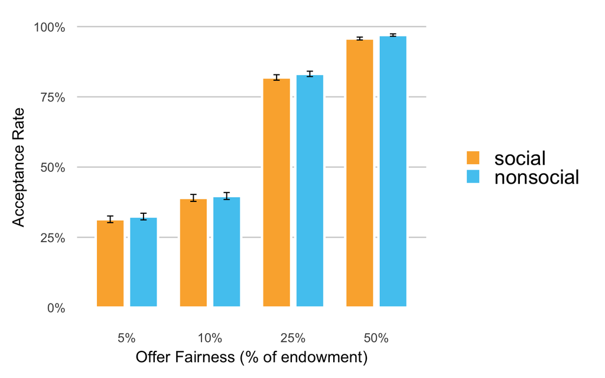

```r
# Summarise with SE and put "social" first
plot_df <- full_df |>
  group_by(beh_fairness_perc, condition) |>
  summarise(n = dplyr::n(),
            accept_rate = mean(accept, na.rm = T),
            sd_accept = sd(accept, na.rm = T),
            se_accept = sd_accept / sqrt(n), .groups = "drop") |>
  mutate(condition = factor(condition, levels = c("social", "nonsocial")),
         ymin = pmax(0, accept_rate - se_accept),
         ymax = pmin(1, accept_rate + se_accept))

pd <- position_dodge(width = 0.8)  # shared dodge object

# Figure 1B
p_fig1b <- ggplot(plot_df, aes(x = beh_fairness_perc, y = accept_rate, fill = condition)) +
  geom_hline(yintercept = c(0.25, 0.50, 0.75, 1.00),
           linetype = "solid",
           color = "lightgray",
           linewidth = 0.6) +
  geom_col(width = 0.7, color = "white", position = pd) +
  geom_errorbar(aes(ymin = ymin, ymax = ymax), width = 0.15, position = pd, linewidth = 0.5) +
  scale_y_continuous(name = "Acceptance Rate",
                     breaks = c(0, 0.25, 0.50, 0.75, 1.00),
                     labels = scales::label_percent(accuracy = 1)) +
  coord_cartesian(ylim = c(0, 1)) +
  scale_x_discrete(name = "Offer Fairness (% of endowment)") +
  scale_fill_manual(values = c("social" = "#FBB03B", "nonsocial" = "#50C9F1"), breaks = c("social", "nonsocial")) +
  theme_minimal(base_size = 24) +
  theme(panel.grid = element_blank(), axis.title = element_text(size = 15), axis.text = element_text(size = 12), legend.title = element_blank())
p_fig1b
```

Significant for offer fairness, but not the interaction term.

## Response time and offer fairness (for supplemental)

Checking whether response time is strongly correlated with offer fairness, since shared variance with the RT regressor could underestimate the parametric fairness effect.

```r
rt_clean <- full_df |>
  filter(!is.na(rt), rt > 0)
nrow(rt_clean)
```

```
## [1] 12430
```

```r
summary(rt_clean$rt) # sanity: should sit under the 3.25s decision window
```

```
##    Min. 1st Qu.  Median    Mean 3rd Qu.    Max.
## 0.03294 0.95024 1.14988 1.23104 1.43346 3.23395
```

```r
# a) within-sub corrs, fisher-z averagde
ws_r <- rt_clean |>
  group_by(sub_id) |>
  summarise(r = cor(beh_fairness_num, rt), .groups = "drop") |>
  mutate(z = atanh(pmin(pmax(r, -.999), .999)))
ws_r |> summarise(n = n(), mean_r = tanh(mean(z)), sd_r = sd(r),
                  min_r = min(r), max_r = max(r),
                  t = mean(z)/(sd(z)/sqrt(n())),
                  p = 2*pt(-abs(t), n()-1))
```

```
## # A tibble: 1 × 7
##       n  mean_r  sd_r  min_r max_r     t             p
##   <int>   <dbl> <dbl>  <dbl> <dbl> <dbl>         <dbl>
## 1   138 -0.0970 0.176 -0.576 0.328 -6.17 0.00000000708
```

```r
t.test(ws_r$r)   # untransformed
```

```
##
##  One Sample t-test
##
## data:  ws_r$r
## t = -6.2128, df = 137, p-value = 0.000000005847
## alternative hypothesis: true mean is not equal to 0
## 95 percent confidence interval:
##  -0.12262623 -0.06341305
## sample estimates:
##   mean of x
## -0.09301964
```

```r
# b) monotonic in fairness, or slowest at intermediate offers?
rt_clean |>
  group_by(beh_fairness_perc) |>
  summarise(M = mean(rt), SD = sd(rt), n = n())
```

```
## # A tibble: 4 × 4
##   beh_fairness_perc     M    SD     n
##   <fct>             <dbl> <dbl> <int>
## 1 5%                 1.23 0.411  3109
## 2 10%                1.26 0.437  3109
## 3 25%                1.29 0.449  3097
## 4 50%                1.15 0.369  3115
```

```r
# Tukey
emmeans(lmer(rt ~ beh_fairness_perc + (1 | sub_id), data = rt_clean), pairwise ~ beh_fairness_perc)
```

```
## Note: D.f. calculations have been disabled because the number of observations exceeds 3000.
## To enable adjustments, add the argument 'pbkrtest.limit = 12430' (or larger)
## [or, globally, 'set emm_options(pbkrtest.limit = 12430)' or larger];
## but be warned that this may result in large computation time and memory use.
```

```
## Note: D.f. calculations have been disabled because the number of observations exceeds 3000.
## To enable adjustments, add the argument 'lmerTest.limit = 12430' (or larger)
## [or, globally, 'set emm_options(lmerTest.limit = 12430)' or larger];
## but be warned that this may result in large computation time and memory use.
```

```
## $emmeans
##  beh_fairness_perc emmean     SE  df asymp.LCL asymp.UCL
##  5%                  1.23 0.0218 Inf      1.19      1.27
##  10%                 1.26 0.0218 Inf      1.22      1.30
##  25%                 1.29 0.0218 Inf      1.25      1.33
##  50%                 1.15 0.0218 Inf      1.11      1.20
##
## Degrees-of-freedom method: asymptotic
## Confidence level used: 0.95
##
## $contrasts
##  contrast  estimate      SE  df z.ratio p.value
##  5% - 10%   -0.0296 0.00867 Inf  -3.419  0.0035
##  5% - 25%   -0.0606 0.00868 Inf  -6.985  <.0001
##  5% - 50%    0.0767 0.00867 Inf   8.846  <.0001
##  10% - 25%  -0.0310 0.00868 Inf  -3.569  0.0020
##  10% - 50%   0.1063 0.00867 Inf  12.266  <.0001
##  25% - 50%   0.1373 0.00868 Inf  15.825  <.0001
##
## Degrees-of-freedom method: asymptotic
## P value adjustment: tukey method for comparing a family of 4 estimates
```

## AINs categorical plot (Figure 3)

Using data from the categorical model in FSL (model 3b, level 1 = 5% offer, and so on) to demonstrate the anterior insula tracking offer fairness regardless of low or high endowment amount. Values (ains_) and varcopes (ains_varcope_) extracted from AIns mask, one column per partner and offer level (pt = % of endowment).

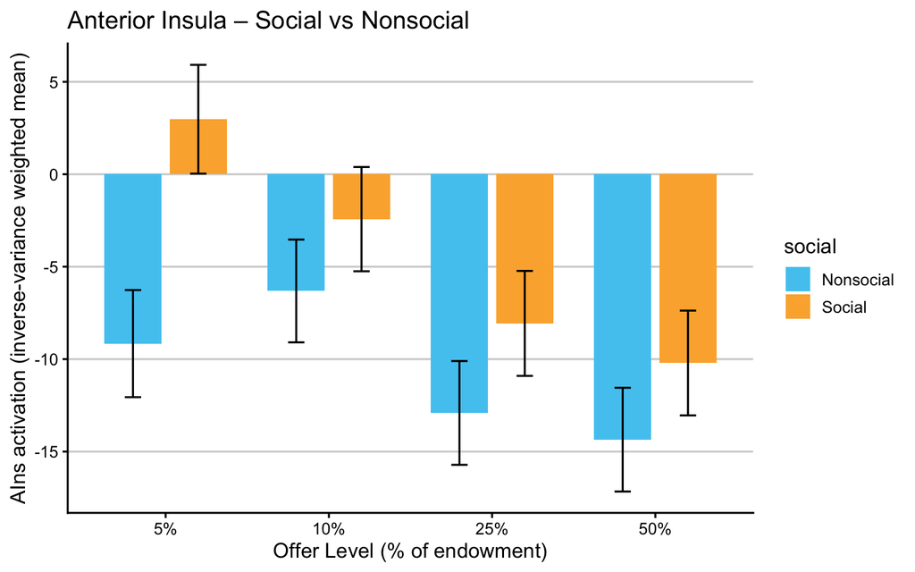

```r
# Long format, one row per sub x condition
cat_stats_df <- df |>
  select(sub_id, starts_with("ains_")) |>
  pivot_longer(-sub_id, names_to = c("stat", "social", "level"),
               names_pattern = "ains_(varcope_)?(social|nonsocial)_(\\d+)pt") |>
  mutate(stat = ifelse(stat == "", "value", "varcope"),
         social = ifelse(social == "nonsocial", "Nonsocial", "Social"),
         level = factor(paste0(level, "%"), levels = c("5%", "10%", "25%", "50%"))) |>
  pivot_wider(names_from = stat, values_from = value)

# Weighted means and SEMs
cat_plot_df <- cat_stats_df |>
  group_by(social, level) |>
  summarise(mean = sum(value / varcope) / sum(1 / varcope), sem = sqrt(1 / sum(1 / varcope)), .groups = "drop")

# Figure 3B
p_fig3b <- ggplot(cat_plot_df, aes(x = level, y = mean, fill = social)) +
  geom_hline(yintercept = c(-15, -10, -5, 0, 5),
           linetype = "solid", color = "lightgray", linewidth = 0.6) +
  geom_col(position = position_dodge(width = 0.8), width = 0.7) +
  geom_errorbar(aes(ymin = mean - sem,
                    ymax = mean + sem),
                position = position_dodge(width = 0.8), width = 0.2, linewidth=0.6) +
  scale_fill_manual(values = c("Social" = "#FBB03B", "Nonsocial" = "#50C9F1")) +
  labs(x = "Offer Level (% of endowment)",
       y = "AIns activation (inverse-variance weighted mean)",
       title = "Anterior Insula – Social vs Nonsocial") +
  theme_classic(base_size = 13)
p_fig3b
```

# Activation

## dlPFC, S > NS behavioral sensitivity, Extrinsic Affect Improving (Other-Directed Affect Improving) (Figure 4, Supplemental Figure 4)

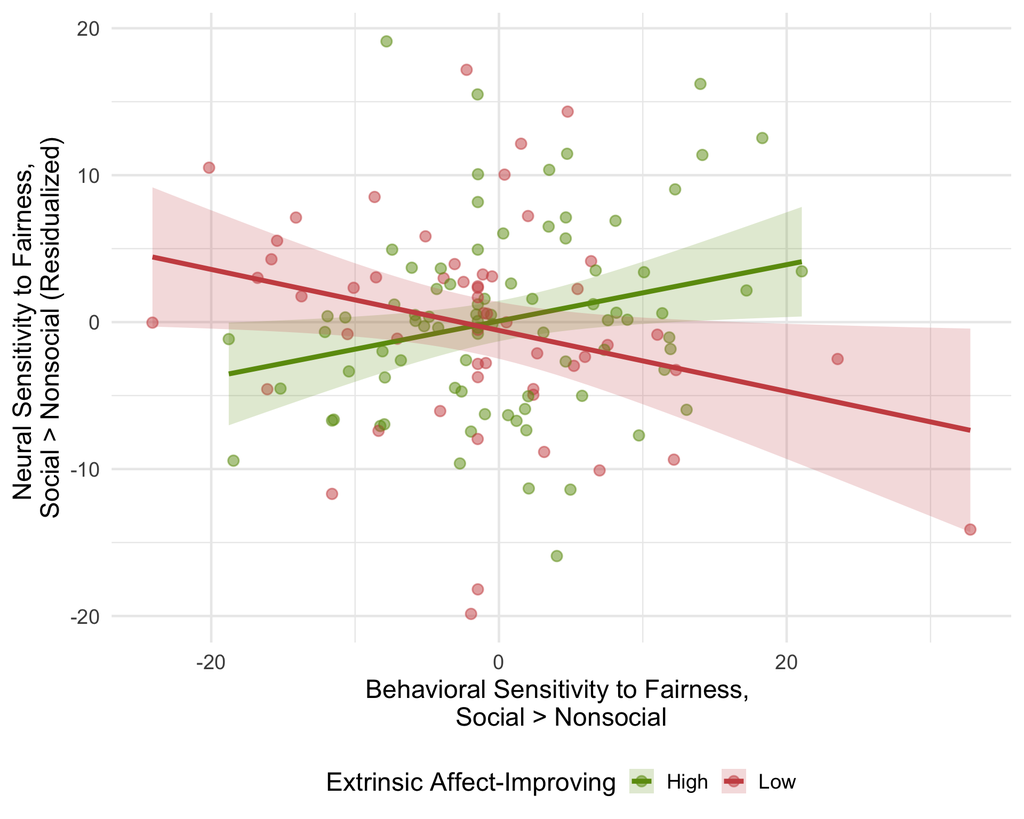

```r
# Create High/Low grouping by median split
df$ext_bet_group <- ifelse(df$ext_bet >= median(df$ext_bet), "High", "Low")

# 12-color color-blind friendly palette
cb_palette <- SteppedSequential5Steps

# Choose colors
cb_pair <- cb_palette[c(3, 11)]
names(cb_pair) <- c("Low", "High")

# Regression scatterplot with colorblind-safe palette and residualized Y (Supp. Figure 4)
p_dlPFC_extbet <- ggplot(df, aes(
  x = diff_slope,
  y = residuals(lm(dlpfc_extbet ~ sub_age_MC + gender_female + gender_male + fd_mean_MC + tsnr_MC)),
  color = ext_bet_group,
  fill = ext_bet_group)) +
  geom_point(alpha = 0.5, size = 3) +
  geom_smooth(method = "lm", se = T, alpha = 0.2) +
  scale_color_manual(values = cb_pair) +
  scale_fill_manual(values = cb_pair) +
  labs(
    x = "Behavioral Sensitivity to Fairness, \nSocial > Nonsocial",
    y = "Neural Sensitivity to Fairness, \nSocial > Nonsocial (Residualized)",
    color = "Extrinsic Affect-Improving",
    fill = "Extrinsic Affect-Improving") +
  theme_minimal(base_size = 18) +
  theme(legend.position="bottom")
p_dlPFC_extbet
```

```r
# Johnson-Neyman plot version (Figure 4B)
m_jn <- lm(dlpfc_extbet ~ diff_slope * ext_bet + sub_age_MC + gender_female + gender_male + fd_mean_MC + tsnr_MC, data = df)
summary(m_jn)
```

```
##
## Call:
## lm(formula = dlpfc_extbet ~ diff_slope * ext_bet + sub_age_MC +
##     gender_female + gender_male + fd_mean_MC + tsnr_MC, data = df)
##
## Residuals:
##      Min       1Q   Median       3Q      Max
## -19.6131  -3.9836   0.7459   3.5848  20.4886
##
## Coefficients:
##                     Estimate Std. Error t value  Pr(>|t|)
## (Intercept)         -1.73294    4.09361  -0.423    0.6728
## diff_slope          -1.46731    0.32755  -4.480 0.0000163 ***
## ext_bet              0.60958    0.75565   0.807    0.4213
## sub_age_MC          -0.01155    0.06202  -0.186    0.8526
## gender_female       -0.23360    3.02219  -0.077    0.9385
## gender_male         -1.39860    3.13918  -0.446    0.6567
## fd_mean_MC         -16.04838    9.26821  -1.732    0.0857 .
## tsnr_MC             -0.16980    0.09344  -1.817    0.0715 .
## diff_slope:ext_bet   0.38866    0.08522   4.561 0.0000117 ***
## ---
## Signif. codes:  0 '***' 0.001 '**' 0.01 '*' 0.05 '.' 0.1 ' ' 1
##
## Residual standard error: 6.465 on 129 degrees of freedom
## Multiple R-squared:  0.1638, Adjusted R-squared:  0.1119
## F-statistic: 3.158 on 8 and 129 DF,  p-value: 0.002679
```

```r
# Observed range of moderator
mf <- model.frame(m_jn)
mod_rng <- range(mf$ext_bet, na.rm = T)

# Johnson–Neyman analysis
jn <- johnson_neyman(m_jn,
  pred = "diff_slope",
  modx = "ext_bet",
  alpha = 0.05,
  mod.range = mod_rng,
  sig.color = cb_palette[11],
  insig.color = "gray",
  line.thickness = 1,
  y.label = "Slope of Sensitivity to Fairness, Social > Nonsocial",
  modx.label = "Extrinsic Affect-Improving",
  title = "Activation, dlPFC, Extrinsic Affect-Improving")
jn
```

```
## JOHNSON-NEYMAN INTERVAL
##
## When ext_bet is OUTSIDE the interval [3.42, 4.13], the slope of diff_slope
## is p < .05.
##
## Note: The range of observed values of ext_bet is [1.67, 5.00]
```

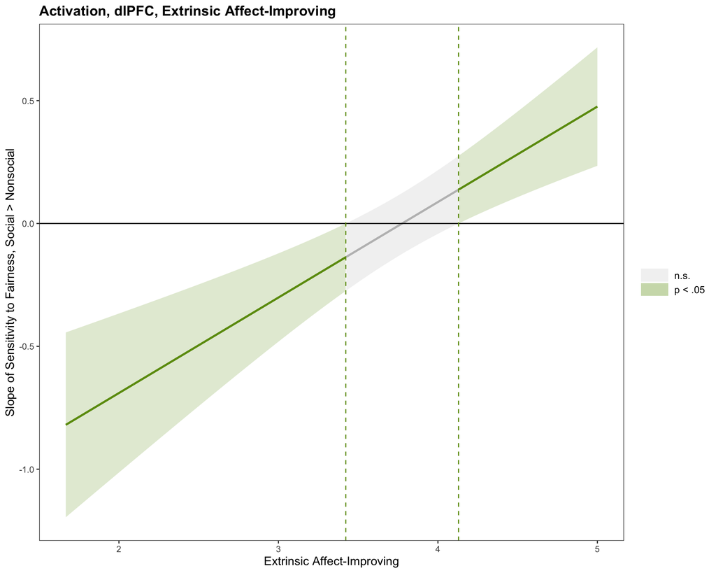

# PPI

## Amygdala, S > NS behavioral sensitivity (Figure 5)

```r
diff_amyg <- lm(amyg_ofc ~ diff_slope + sub_age_MC + gender_female + gender_male + fd_mean_MC + tsnr_MC, data = df)
summary(diff_amyg)
```

```
##
## Call:
## lm(formula = amyg_ofc ~ diff_slope + sub_age_MC + gender_female +
##     gender_male + fd_mean_MC + tsnr_MC, data = df)
##
## Residuals:
##      Min       1Q   Median       3Q      Max
## -0.61778 -0.06332  0.01036  0.06553  0.65204
##
## Coefficients:
##                Estimate Std. Error t value Pr(>|t|)
## (Intercept)   -0.019062   0.071487  -0.267  0.79016
## diff_slope     0.004526   0.001520   2.978  0.00346 **
## sub_age_MC    -0.001962   0.001494  -1.313  0.19133
## gender_female  0.019821   0.073205   0.271  0.78700
## gender_male    0.040787   0.076171   0.535  0.59323
## fd_mean_MC     0.156572   0.221338   0.707  0.48058
## tsnr_MC       -0.001105   0.002262  -0.489  0.62585
## ---
## Signif. codes:  0 '***' 0.001 '**' 0.01 '*' 0.05 '.' 0.1 ' ' 1
##
## Residual standard error: 0.1571 on 131 degrees of freedom
## Multiple R-squared:  0.08872,    Adjusted R-squared:  0.04698
## F-statistic: 2.126 on 6 and 131 DF,  p-value: 0.05453
```

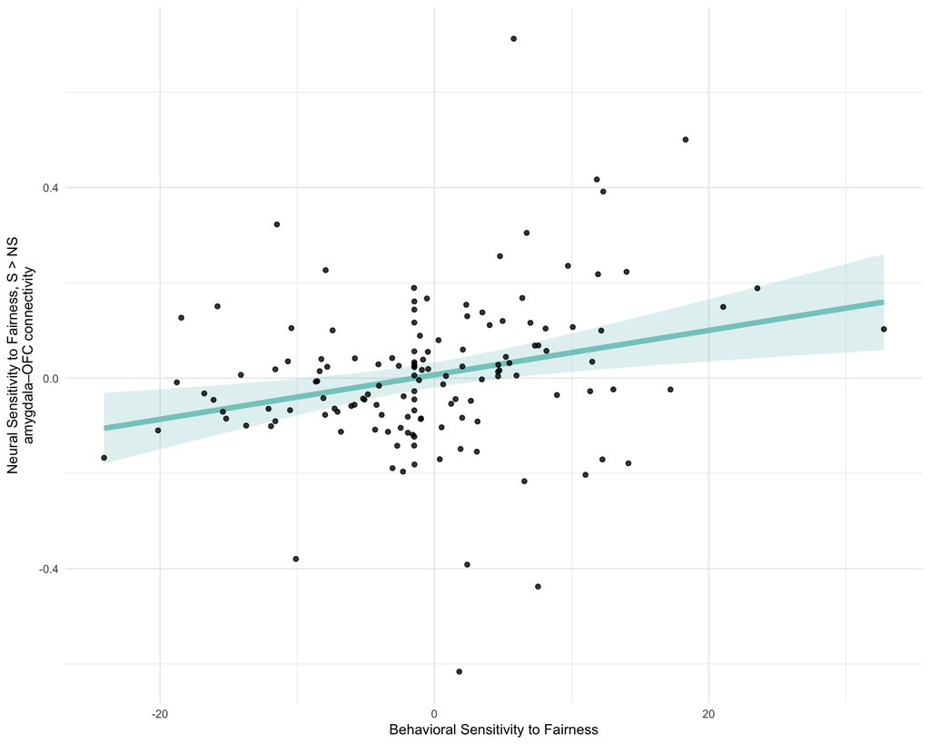

```r
# Figure 5B
p_amygdala_ofc <- ggplot(df, aes(x = diff_slope, y = amyg_ofc)) +
  geom_smooth(method = "lm", formula = y ~ x,
    se = T, color = "#85CAC7", fill = "#85CAC7", linewidth = 2, alpha = 0.25) +
    geom_point(color = "black", size = 1.5, alpha = 0.8) +
  labs(x = "Behavioral Sensitivity to Fairness",
       y = "Neural Sensitivity to Fairness, S > NS\namygdala–OFC connectivity") +
  theme_minimal() +
  theme(legend.position="top")
p_amygdala_ofc
```

## Amygdala-dmPFC, S > NS behavioral sensitivity, Extrinsic Worsening (Other-Directed Affect Worsening) (Figure 6, Supplemental Figure 5)

```r
# amygdala
model_amyg <- lm(amyg_dmpfc ~ sub_age_MC + gender_female + gender_male + fd_mean_MC + tsnr_MC + diff_slope + ext_wor + (diff_slope*ext_wor), data=df)
summary(model_amyg)
```

```
##
## Call:
## lm(formula = amyg_dmpfc ~ sub_age_MC + gender_female + gender_male +
##     fd_mean_MC + tsnr_MC + diff_slope + ext_wor + (diff_slope *
##     ext_wor), data = df)
##
## Residuals:
##       Min        1Q    Median        3Q       Max
## -0.239567 -0.053842  0.005574  0.054740  0.285060
##
## Coefficients:
##                      Estimate Std. Error t value   Pr(>|t|)
## (Intercept)        -0.0483068  0.0517525  -0.933      0.352
## sub_age_MC          0.0004973  0.0009172   0.542      0.589
## gender_female       0.0088361  0.0448432   0.197      0.844
## gender_male         0.0354071  0.0466412   0.759      0.449
## fd_mean_MC          0.0597227  0.1350751   0.442      0.659
## tsnr_MC             0.0017957  0.0013807   1.301      0.196
## diff_slope         -0.0143965  0.0030641  -4.698 0.00000662 ***
## ext_wor             0.0183583  0.0171673   1.069      0.287
## diff_slope:ext_wor  0.0108130  0.0022168   4.878 0.00000310 ***
## ---
## Signif. codes:  0 '***' 0.001 '**' 0.01 '*' 0.05 '.' 0.1 ' ' 1
##
## Residual standard error: 0.09573 on 129 degrees of freedom
## Multiple R-squared:  0.1668, Adjusted R-squared:  0.1151
## F-statistic: 3.227 on 8 and 129 DF,  p-value: 0.002231
```

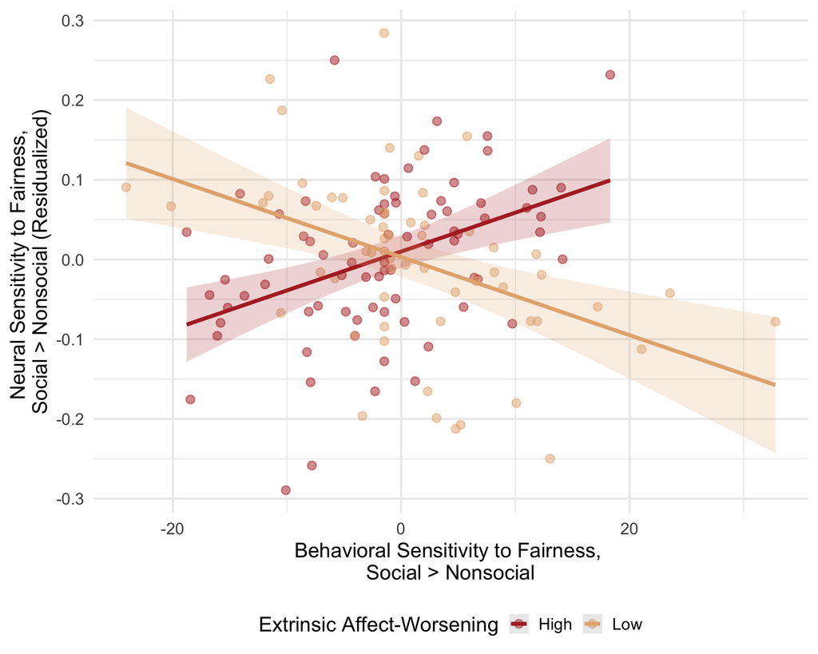

```r
# Create High/Low grouping by median split
df$extwor_group <- ifelse(df$ext_wor >= median(df$ext_wor), "High", "Low")

# Colors
cbextwor_pair <- SteppedSequential5Steps[c(2, 9)]
names(cbextwor_pair) <- c("High", "Low")

# Regression scatterplot with residualized Y (Supp Figure 5)
p_amygdala_extwor <- ggplot(df, aes(x = diff_slope,
  y = residuals(lm(amyg_dmpfc ~ sub_age_MC + gender_female + gender_male + fd_mean_MC + tsnr_MC)),
  color = extwor_group, fill = extwor_group)) +
  geom_point(alpha = 0.5, size = 3) +
  geom_smooth(method = "lm", se = T, alpha = 0.2) +
  scale_color_manual(values = cbextwor_pair) +
  scale_fill_manual(values = cbextwor_pair) +
  labs(x = "Behavioral Sensitivity to Fairness, \nSocial > Nonsocial",
    y = "Neural Sensitivity to Fairness, \nSocial > Nonsocial (Residualized)",
    color = "Extrinsic Affect-Worsening") +
  theme_minimal(base_size = 18) +
  guides(fill = "none", shape = "none") +
  theme(legend.position="bottom")
p_amygdala_extwor
```

```
## JOHNSON-NEYMAN INTERVAL
##
## When ext_wor is OUTSIDE the interval [1.15, 1.52], the slope of diff_slope
## is p < .05.
##
## Note: The range of observed values of ext_wor is [1.00, 3.00]
```

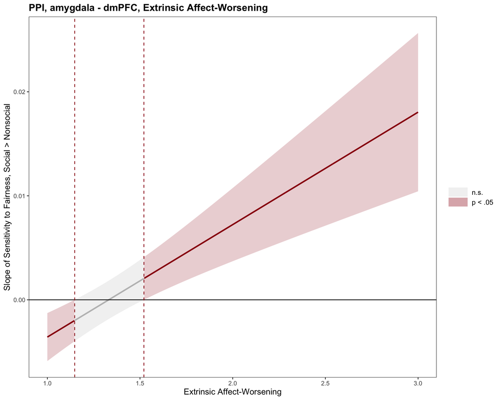

```r
# Johnson-Neyman plot version (Figure 6B)
m_jn2 <- lm(amyg_dmpfc ~ diff_slope * ext_wor + sub_age_MC + gender_female + gender_male + fd_mean_MC + tsnr_MC, data = df)

# Obs range of moderator
mf2 <- model.frame(m_jn2)
mod_rng2 <- range(mf2$ext_wor, na.rm = T)

# Johnson–Neyman
jn2 <- johnson_neyman(m_jn2,
  pred = "diff_slope",
  modx = "ext_wor",
  alpha = 0.05,
  mod.range = mod_rng2,
  sig.color = cb_palette[1],
  insig.color = "gray",
  line.thickness = 1,
  y.label = "Slope of Sensitivity to Fairness, Social > Nonsocial",
  modx.label = "Extrinsic Affect-Worsening",
  title = "PPI, amygdala - dmPFC, Extrinsic Affect-Worsening")
jn2
```

# Behavioral Plots

## Overall fairness (Supplemental Figure 1)

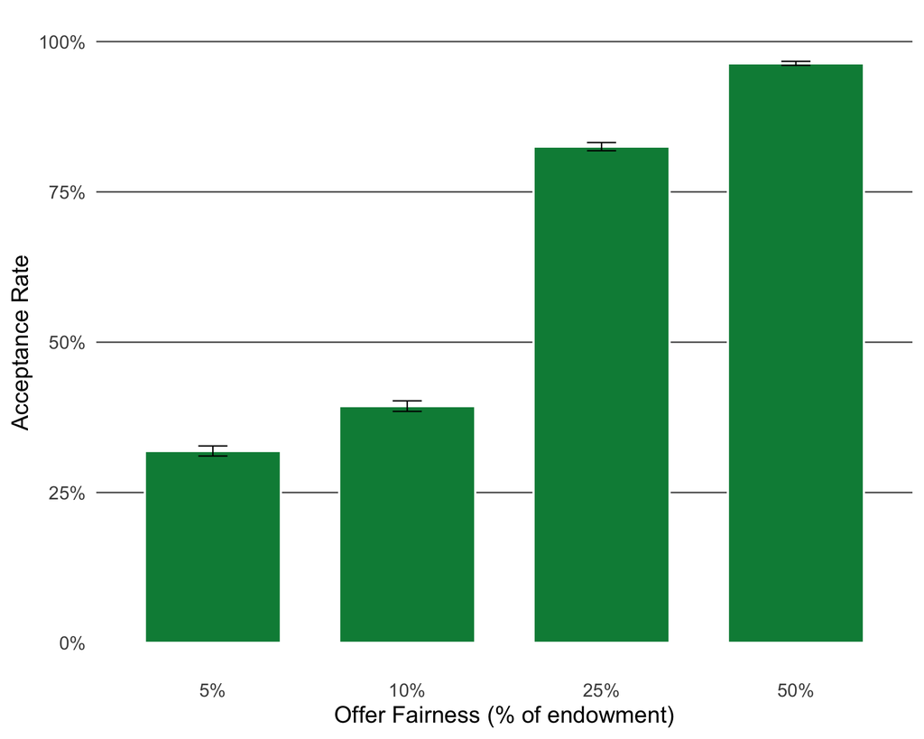

```r
# Supp. Figure 1: offer fairness (task-defined, 5, 10, 25, 50% of offer)
plot_df_fairness <- full_df |>
  group_by(beh_fairness_perc) |>
  summarise(n = dplyr::n(),
    accept_rate = mean(accept, na.rm = T),
    sd_accept = sd(accept, na.rm = T),
    se_accept = sd_accept / sqrt(n), .groups = "drop") |>
  mutate(ymin = pmax(0, accept_rate - se_accept),
         ymax = pmin(1, accept_rate + se_accept))

p_supp_fairness <- ggplot(plot_df_fairness, aes(x = beh_fairness_perc, y = accept_rate)) +
  geom_hline(yintercept = c(0.25, 0.50, 0.75, 1.00), linetype = "solid", color = "gray40", linewidth = 0.6) +
  geom_col(width = 0.7, fill = "springgreen4", color = "white") +
  geom_errorbar(aes(ymin = ymin, ymax = ymax), width = 0.15, linewidth = 0.5) +
  scale_y_continuous(name = "Acceptance Rate",
    breaks = c(0, 0.25, 0.50, 0.75, 1.00),
    labels = scales::label_percent(accuracy = 1)) +
  coord_cartesian(ylim = c(0, 1)) +
  scale_x_discrete(name = "Offer Fairness (% of endowment)") +
  theme_minimal(base_size = 18) +
  theme(panel.grid = element_blank(), legend.position = "none")
p_supp_fairness
```

## EROS moderation of fairness sensitivity (trial-level) (Figure 2)

```r
eros_cols <- c("Other-Directed Emotion Improving" = "green3",
               "Other-Directed Emotion Worsening" = "red2",
               "Self-Directed Emotion Improving"  = "goldenrod2",
               "Self-Directed Emotion Worsening"  = "blue2")

# Z-score fairness and add mean-centered EROS scores to the trial-level df
full_df$fair_z <- scale(full_df$beh_fairness)[,1]
  full_df <- full_df |> select(-any_of(c("ext_bet_c", "ext_wor_c", "int_bet_c", "int_wor_c"))) |>
    left_join(select(df, sub_id, ext_bet_c, ext_wor_c, int_bet_c, int_wor_c), by = "sub_id")
fair_mean <- mean(full_df$beh_fairness, na.rm = T)
fair_sd <- sd(full_df$beh_fairness, na.rm = T)

# EROS moderation of fairness x offer acceptance relationship (all trials)
fair_extbet <- glmer(accept ~ fair_z * ext_bet_c + (1 + fair_z | sub_id), family = binomial, data = full_df,
                     control = glmerControl(optimizer = "bobyqa", optCtrl = list(maxfun = 100000)))
fair_extwor <- glmer(accept ~ fair_z * ext_wor_c + (1 + fair_z | sub_id), family = binomial, data = full_df,
                     control = glmerControl(optimizer = "bobyqa", optCtrl = list(maxfun = 100000)))
fair_intbet <- glmer(accept ~ fair_z * int_bet_c + (1 + fair_z | sub_id), family = binomial, data = full_df,
                     control = glmerControl(optimizer = "bobyqa", optCtrl = list(maxfun = 100000)))
fair_intwor <- glmer(accept ~ fair_z * int_wor_c + (1 + fair_z | sub_id), family = binomial, data = full_df,
                     control = glmerControl(optimizer = "bobyqa", optCtrl = list(maxfun = 100000)))
summary(fair_extbet)
```

```
## Generalized linear mixed model fit by maximum likelihood (Laplace
##   Approximation) [glmerMod]
##  Family: binomial  ( logit )
## Formula: accept ~ fair_z * ext_bet_c + (1 + fair_z | sub_id)
##    Data: full_df
## Control: glmerControl(optimizer = "bobyqa", optCtrl = list(maxfun = 100000))
##
##      AIC      BIC   logLik deviance df.resid
##   6752.8   6804.8  -3369.4   6738.8    12423
##
## Scaled residuals:
##      Min       1Q   Median       3Q      Max
## -136.012   -0.194    0.035    0.216   11.672
##
## Random effects:
##  Groups Name        Variance Std.Dev. Corr
##  sub_id (Intercept) 5.626    2.372
##         fair_z      5.363    2.316    -0.38
## Number of obs: 12430, groups:  sub_id, 138
##
## Fixed effects:
##                  Estimate Std. Error z value            Pr(>|z|)
## (Intercept)       1.89536    0.21658   8.751 <0.0000000000000002 ***
## fair_z            3.36697    0.22455  14.995 <0.0000000000000002 ***
## ext_bet_c         0.03769    0.27874   0.135               0.892
## fair_z:ext_bet_c -0.38799    0.28997  -1.338               0.181
## ---
## Signif. codes:  0 '***' 0.001 '**' 0.01 '*' 0.05 '.' 0.1 ' ' 1
##
## Correlation of Fixed Effects:
##             (Intr) fair_z ext_b_
## fair_z      -0.231
## ext_bet_c   -0.013 -0.005
## fr_z:xt_bt_ -0.009 -0.039 -0.293
```

```r
summary(fair_extwor)
```

```
## Generalized linear mixed model fit by maximum likelihood (Laplace
##   Approximation) [glmerMod]
##  Family: binomial  ( logit )
## Formula: accept ~ fair_z * ext_wor_c + (1 + fair_z | sub_id)
##    Data: full_df
## Control: glmerControl(optimizer = "bobyqa", optCtrl = list(maxfun = 100000))
##
##      AIC      BIC   logLik deviance df.resid
##   6750.1   6802.1  -3368.1   6736.1    12423
##
## Scaled residuals:
##      Min       1Q   Median       3Q      Max
## -146.904   -0.192    0.037    0.213   11.869
##
## Random effects:
##  Groups Name        Variance Std.Dev. Corr
##  sub_id (Intercept) 5.519    2.349
##         fair_z      5.208    2.282    -0.37
## Number of obs: 12430, groups:  sub_id, 138
##
## Fixed effects:
##                  Estimate Std. Error z value            Pr(>|z|)
## (Intercept)        1.8940     0.2148   8.817 <0.0000000000000002 ***
## fair_z             3.3581     0.2219  15.133 <0.0000000000000002 ***
## ext_wor_c         -0.5069     0.4255  -1.191              0.2336
## fair_z:ext_wor_c   0.8873     0.4347   2.041              0.0412 *
## ---
## Signif. codes:  0 '***' 0.001 '**' 0.01 '*' 0.05 '.' 0.1 ' ' 1
##
## Correlation of Fixed Effects:
##             (Intr) fair_z ext_w_
## fair_z      -0.218
## ext_wor_c   -0.016 -0.003
## fr_z:xt_wr_  0.003  0.009 -0.284
```

```r
summary(fair_intbet)
```

```
## Generalized linear mixed model fit by maximum likelihood (Laplace
##   Approximation) [glmerMod]
##  Family: binomial  ( logit )
## Formula: accept ~ fair_z * int_bet_c + (1 + fair_z | sub_id)
##    Data: full_df
## Control: glmerControl(optimizer = "bobyqa", optCtrl = list(maxfun = 100000))
##
##      AIC      BIC   logLik deviance df.resid
##   6753.6   6805.6  -3369.8   6739.6    12423
##
## Scaled residuals:
##      Min       1Q   Median       3Q      Max
## -136.300   -0.194    0.035    0.215   11.997
##
## Random effects:
##  Groups Name        Variance Std.Dev. Corr
##  sub_id (Intercept) 5.572    2.36
##         fair_z      5.429    2.33     -0.38
## Number of obs: 12430, groups:  sub_id, 138
##
## Fixed effects:
##                  Estimate Std. Error z value            Pr(>|z|)
## (Intercept)       1.89595    0.21574   8.788 <0.0000000000000002 ***
## fair_z            3.36139    0.22557  14.902 <0.0000000000000002 ***
## int_bet_c        -0.30296    0.34085  -0.889               0.374
## fair_z:int_bet_c -0.07091    0.35120  -0.202               0.840
## ---
## Signif. codes:  0 '***' 0.001 '**' 0.01 '*' 0.05 '.' 0.1 ' ' 1
##
## Correlation of Fixed Effects:
##             (Intr) fair_z int_b_
## fair_z      -0.235
## int_bet_c   -0.017 -0.009
## fr_z:nt_bt_ -0.008 -0.022 -0.298
```

```r
summary(fair_intwor)
```

```
## Generalized linear mixed model fit by maximum likelihood (Laplace
##   Approximation) [glmerMod]
##  Family: binomial  ( logit )
## Formula: accept ~ fair_z * int_wor_c + (1 + fair_z | sub_id)
##    Data: full_df
## Control: glmerControl(optimizer = "bobyqa", optCtrl = list(maxfun = 100000))
##
##      AIC      BIC   logLik deviance df.resid
##   6751.5   6803.5  -3368.8   6737.5    12423
##
## Scaled residuals:
##      Min       1Q   Median       3Q      Max
## -126.801   -0.196    0.034    0.209   11.791
##
## Random effects:
##  Groups Name        Variance Std.Dev. Corr
##  sub_id (Intercept) 5.538    2.353
##         fair_z      5.260    2.293    -0.38
## Number of obs: 12430, groups:  sub_id, 138
##
## Fixed effects:
##                  Estimate Std. Error z value            Pr(>|z|)
## (Intercept)        1.8935     0.2152   8.800 <0.0000000000000002 ***
## fair_z             3.3548     0.2227  15.061 <0.0000000000000002 ***
## int_wor_c         -0.2521     0.2994  -0.842              0.3999
## fair_z:int_wor_c   0.5253     0.3043   1.726              0.0843 .
## ---
## Signif. codes:  0 '***' 0.001 '**' 0.01 '*' 0.05 '.' 0.1 ' ' 1
##
## Correlation of Fixed Effects:
##             (Intr) fair_z int_w_
## fair_z      -0.227
## int_wor_c   -0.023 -0.004
## fr_z:nt_wr_  0.000 -0.002 -0.284
```

```r
# EROS moderation of fairness x offer acceptance relationship (social vs. nonsocial trials)
fair_extwor_cond <- glmer(accept ~ fair_z * ext_wor_c * condition + (1 + fair_z | sub_id), family = binomial, data = full_df,
                          control = glmerControl(optimizer = "bobyqa", optCtrl = list(maxfun = 100000)))
summary(fair_extwor_cond)$coefficients["fair_z:ext_wor_c:conditionsocial", ]
```

```
##   Estimate Std. Error    z value   Pr(>|z|)
## -0.3004379  0.2141909 -1.4026643  0.1607170
```

```r
fair_extbet_cond <- glmer(accept ~ fair_z * ext_bet_c * condition + (1 + fair_z | sub_id), family = binomial, data = full_df,
                          control = glmerControl(optimizer = "bobyqa", optCtrl = list(maxfun = 100000)))
fair_intbet_cond <- glmer(accept ~ fair_z * int_bet_c * condition + (1 + fair_z | sub_id), family = binomial, data = full_df,
                          control = glmerControl(optimizer = "bobyqa", optCtrl = list(maxfun = 100000)))
fair_intwor_cond <- glmer(accept ~ fair_z * int_wor_c * condition + (1 + fair_z | sub_id), family = binomial, data = full_df,
                          control = glmerControl(optimizer = "bobyqa", optCtrl = list(maxfun = 100000)))

cond_p <- c(ext_bet = summary(fair_extbet_cond)$coefficients["fair_z:ext_bet_c:conditionsocial", 4],
            ext_wor = summary(fair_extwor_cond)$coefficients["fair_z:ext_wor_c:conditionsocial", 4],
            int_bet = summary(fair_intbet_cond)$coefficients["fair_z:int_bet_c:conditionsocial", 4],
            int_wor = summary(fair_intwor_cond)$coefficients["fair_z:int_wor_c:conditionsocial", 4])
cond_p
```

```
##    ext_bet    ext_wor    int_bet    int_wor
## 0.30941868 0.16071696 0.04962082 0.48024913
```

```r
p.adjust(cond_p, "bonferroni")
```

```
##   ext_bet   ext_wor   int_bet   int_wor
## 1.0000000 0.6428678 0.1984833 1.0000000
```

```r
# Vars to use for plot
eros_vars <- c("ext_bet_c", "ext_wor_c", "int_bet_c", "int_wor_c")

fig2_df <- list(fair_extbet, fair_extwor, fair_intbet, fair_intwor) |>
  set_names(eros_vars) |>
  imap_dfr(\(m, v) broom.mixed::tidy(m, effects = "fixed", conf.int = TRUE) |> # Wald 95% CIs
             filter(term == paste0("fair_z:", v)) |>
             mutate(var = v)) |>
  mutate(sd_sub   = map_dbl(sub("_c$", "", var), \(r) sd(df[[r]])),
         est_sd   = estimate  * sd_sub,
         low_sd   = conf.low  * sd_sub,
         high_sd  = conf.high * sd_sub,
         p_bonf   = p.adjust(p.value, "bonferroni"),
         EROS_scale = factor(names(eros_cols)[match(var, eros_vars)], levels = rev(names(eros_cols))))

print(select(fig2_df, EROS_scale, estimate, std.error, statistic, p.value, p_bonf, est_sd), digits = 4)
```

```
## # A tibble: 4 × 7
##   EROS_scale                 estimate std.error statistic p.value p_bonf  est_sd
##   <fct>                         <dbl>     <dbl>     <dbl>   <dbl>  <dbl>   <dbl>
## 1 Other-Directed Emotion Im…  -0.388      0.290    -1.34   0.181   0.724 -0.296
## 2 Other-Directed Emotion Wo…   0.887      0.435     2.04   0.0412  0.165  0.436
## 3 Self-Directed Emotion Imp…  -0.0709     0.351    -0.202  0.840   1     -0.0441
## 4 Self-Directed Emotion Wor…   0.525      0.304     1.73   0.0843  0.337  0.372
```

```r
# Figure 2
# Panel A: forest plot, per SD of each subscale
x_lim <- max(abs(c(fig2_df$low_sd, fig2_df$high_sd))) * 1.1

p_fig2a <- ggplot(fig2_df, aes(x = est_sd, y = EROS_scale, color = EROS_scale)) +
  geom_vline(xintercept = 0, linetype = "dashed", color = "gray40", linewidth = 0.9) +
  geom_pointrange(aes(xmin = low_sd, xmax = high_sd), linewidth = 1.6, size = 1.5) +
  annotate("text", x = -0.03, y = 0.4, label = "Fairness matters less", hjust = 1, size = 5.5, color = "black") +
  annotate("text", x =  0.03, y = 0.4, label = "Fairness matters more", hjust = 0, size = 5.5, color = "black") +
  scale_x_continuous(limits = c(-x_lim, x_lim), breaks = seq(-1, 1, by = 0.5)) +
  scale_y_discrete(expand = expansion(add = c(0.9, 0.5))) +
  scale_color_manual(values = eros_cols, breaks = names(eros_cols), name = NULL) +
  guides(color = guide_legend(nrow = 2, override.aes = list(linewidth = 1.6, size = 1.2))) +
  labs(x = "Effect of a 1-SD higher EROS score\non fairness sensitivity (log-odds)", y = NULL) +
  theme_minimal(base_size = 20) +
  theme(panel.grid = element_blank(),
        axis.text.y = element_blank(),
        axis.line.x = element_line(color = "black"),
        axis.ticks.x = element_line(color = "black"),
        axis.ticks.length.x = unit(5, "pt"),
        axis.text.x = element_text(size = 17),
        axis.title = element_text(size = 18),
        legend.position = "bottom",
        legend.text = element_text(size = 16),
        legend.margin = margin(0, 0, 0, 0),
        legend.box.spacing = unit(4, "pt"),
        legend.key.height = unit(14, "pt"),
        plot.tag = element_text(size = 24, face = "bold"))

# Panel B: predicted acceptance, other-directed emotion worsening
# Typical participant (random effects = 0), at the four offer levels, for the
# scale minimum, the mean, and +1 SD (-1 SD would fall below the scale minimum of 1).
offers <- c(0.05, 0.10, 0.25, 0.50)
offers_z <- round((offers - fair_mean) / fair_sd, 4)

eaw_center <- mean(df$ext_wor)
eaw_raw <- c(1.00, eaw_center, eaw_center + sd(df$ext_wor))
eaw_labs <- sprintf(c("%.2f (scale minimum)", "%.2f (mean)", "%.2f (+1 SD)"), eaw_raw)

pred_eaw <- ggpredict(
  fair_extwor,
  terms = c(sprintf("fair_z [%s]", paste(offers_z, collapse = ",")),
            sprintf("ext_wor_c [%s]", paste(round(eaw_raw - eaw_center, 4), collapse = ",")))) |>
  as.data.frame() |>
  mutate(offer = x * fair_sd + fair_mean,
         eaw = factor(as.numeric(as.character(group)), labels = eaw_labs))
```

```
## You are calculating adjusted predictions on the population-level (i.e.
##   `type = "fixed"`) for a *generalized* linear mixed model.
##   This may produce biased estimates due to Jensen's inequality. Consider
##   setting `bias_correction = TRUE` to correct for this bias.
##   See also the documentation of the `bias_correction` argument.
```

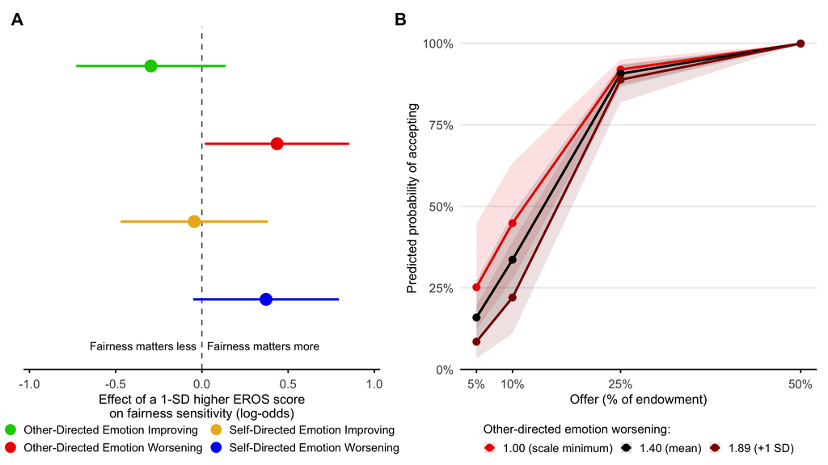

```r
eaw_cols <- setNames(c("red2", "black", "red4"), eaw_labs)

p_fig2b <- ggplot(pred_eaw, aes(x = offer, y = predicted, color = eaw, fill = eaw)) +
  geom_ribbon(aes(ymin = conf.low, ymax = conf.high), alpha = 0.12, color = NA) +
  geom_line(linewidth = 1.6) +
  geom_point(size = 4) +
  scale_color_manual(values = eaw_cols) +
  scale_fill_manual(values = eaw_cols) +
  scale_x_continuous("Offer (% of endowment)", breaks = offers,
                     labels = scales::label_percent(accuracy = 1)) +
  scale_y_continuous("Predicted probability of accepting",
                     limits = c(0, 1), expand = expansion(mult = c(0, 0.05)),
                     labels = scales::label_percent(accuracy = 1)) +
  labs(color = "Other-directed emotion worsening:", fill = "Other-directed emotion worsening:") +
  theme_minimal(base_size = 20) +
  theme(panel.grid.minor = element_blank(),
        panel.grid.major.x = element_blank(),
        axis.line.x = element_line(color = "black"),
        axis.ticks.x = element_line(color = "black"),
        axis.ticks.length.x = unit(5, "pt"),
        legend.position = "bottom",
        legend.direction = "horizontal",
        legend.title.position = "top",
        legend.margin = margin(0, 0, 0, 0),
        legend.box.spacing = unit(4, "pt"),
        legend.text = element_text(size = 16),
        legend.title = element_text(size = 17),
        axis.text = element_text(size = 17),
        axis.title = element_text(size = 18),
        plot.tag = element_text(size = 24, face = "bold"))

# Combine
p_fig2 <- p_fig2a + p_fig2b + plot_annotation(tag_levels = "A")
p_fig2
```

## Subject-specific fairness slopes (Supplemental Figure 2)

```r
# All trials
ext_bet_all <- lm(slope_all ~ ext_bet_c + sub_age_MC + gender_female + gender_male, df)
ext_wor_all <- lm(slope_all ~ ext_wor_c + sub_age_MC + gender_female + gender_male, df)
int_bet_all <- lm(slope_all ~ int_bet_c + sub_age_MC + gender_female + gender_male, df)
int_wor_all <- lm(slope_all ~ int_wor_c + sub_age_MC + gender_female + gender_male, df)
summary(ext_bet_all)
```

```
##
## Call:
## lm(formula = slope_all ~ ext_bet_c + sub_age_MC + gender_female +
##     gender_male, data = df)
##
## Residuals:
##     Min      1Q  Median      3Q     Max
## -24.013 -10.184   1.049   8.955  26.904
##
## Coefficients:
##               Estimate Std. Error t value Pr(>|t|)
## (Intercept)   22.54577    5.20550   4.331 0.000029 ***
## ext_bet_c     -1.88052    1.31552  -1.429    0.155
## sub_age_MC     0.07429    0.10237   0.726    0.469
## gender_female -3.87399    5.35481  -0.723    0.471
## gender_male   -6.43927    5.49123  -1.173    0.243
## ---
## Signif. codes:  0 '***' 0.001 '**' 0.01 '*' 0.05 '.' 0.1 ' ' 1
##
## Residual standard error: 11.51 on 133 degrees of freedom
## Multiple R-squared:  0.03073,    Adjusted R-squared:  0.001574
## F-statistic: 1.054 on 4 and 133 DF,  p-value: 0.382
```

```r
summary(ext_wor_all)
```

```
##
## Call:
## lm(formula = slope_all ~ ext_wor_c + sub_age_MC + gender_female +
##     gender_male, data = df)
##
## Residuals:
##     Min      1Q  Median      3Q     Max
## -23.050  -9.095   1.131   8.960  26.067
##
## Coefficients:
##               Estimate Std. Error t value  Pr(>|t|)
## (Intercept)   21.85609    5.17651   4.222 0.0000446 ***
## ext_wor_c      4.24271    1.99589   2.126    0.0354 *
## sub_age_MC     0.08483    0.10142   0.836    0.4044
## gender_female -3.35231    5.31621  -0.631    0.5294
## gender_male   -5.34442    5.46826  -0.977    0.3302
## ---
## Signif. codes:  0 '***' 0.001 '**' 0.01 '*' 0.05 '.' 0.1 ' ' 1
##
## Residual standard error: 11.41 on 133 degrees of freedom
## Multiple R-squared:  0.04817,    Adjusted R-squared:  0.01955
## F-statistic: 1.683 on 4 and 133 DF,  p-value: 0.1577
```

```r
summary(int_bet_all)
```

```
##
## Call:
## lm(formula = slope_all ~ int_bet_c + sub_age_MC + gender_female +
##     gender_male, data = df)
##
## Residuals:
##     Min      1Q  Median      3Q     Max
## -24.828 -10.510   1.252   9.451  24.486
##
## Coefficients:
##               Estimate Std. Error t value  Pr(>|t|)
## (Intercept)   22.94536    5.23765   4.381 0.0000238 ***
## int_bet_c     -0.20735    1.61481  -0.128     0.898
## sub_age_MC     0.07887    0.10315   0.765     0.446
## gender_female -4.46422    5.38141  -0.830     0.408
## gender_male   -6.51043    5.53428  -1.176     0.242
## ---
## Signif. codes:  0 '***' 0.001 '**' 0.01 '*' 0.05 '.' 0.1 ' ' 1
##
## Residual standard error: 11.6 on 133 degrees of freedom
## Multiple R-squared:  0.01596,    Adjusted R-squared:  -0.01364
## F-statistic: 0.5391 on 4 and 133 DF,  p-value: 0.7072
```

```r
summary(int_wor_all)
```

```
##
## Call:
## lm(formula = slope_all ~ int_wor_c + sub_age_MC + gender_female +
##     gender_male, data = df)
##
## Residuals:
##     Min      1Q  Median      3Q     Max
## -24.125  -9.523   1.082   8.903  26.751
##
## Coefficients:
##               Estimate Std. Error t value  Pr(>|t|)
## (Intercept)   22.87561    5.19042   4.407 0.0000214 ***
## int_wor_c      2.27290    1.45789   1.559     0.121
## sub_age_MC     0.08671    0.10228   0.848     0.398
## gender_female -4.75881    5.33270  -0.892     0.374
## gender_male   -5.72046    5.50564  -1.039     0.301
## ---
## Signif. codes:  0 '***' 0.001 '**' 0.01 '*' 0.05 '.' 0.1 ' ' 1
##
## Residual standard error: 11.5 on 133 degrees of freedom
## Multiple R-squared:  0.0335, Adjusted R-squared:  0.004429
## F-statistic: 1.152 on 4 and 133 DF,  p-value: 0.3349
```

```r
# Multiple comparisons correction across 4 subscales
all_p <- c(ext_bet = summary(ext_bet_all)$coefficients["ext_bet_c", 4],
           ext_wor = summary(ext_wor_all)$coefficients["ext_wor_c", 4],
           int_bet = summary(int_bet_all)$coefficients["int_bet_c", 4],
           int_wor = summary(int_wor_all)$coefficients["int_wor_c", 4])
p.adjust(all_p, method = "bonferroni")
```

```
##   ext_bet   ext_wor   int_bet   int_wor
## 0.6208383 0.1414970 1.0000000 0.4854586
```

```r
p.adjust(all_p, method = "BH")
```

```
##   ext_bet   ext_wor   int_bet   int_wor
## 0.2069461 0.1414970 0.8980213 0.2069461
```

```r
# S>NS difference
summary(lm(diff_slope ~ ext_bet_c + sub_age_MC + gender_female + gender_male, df))
```

```
##
## Call:
## lm(formula = diff_slope ~ ext_bet_c + sub_age_MC + gender_female +
##     gender_male, data = df)
##
## Residuals:
##     Min      1Q  Median      3Q     Max
## -22.779  -4.586  -0.481   4.902  32.275
##
## Coefficients:
##               Estimate Std. Error t value Pr(>|t|)
## (Intercept)   -2.16244    4.08328  -0.530    0.597
## ext_bet_c      0.27920    1.03192   0.271    0.787
## sub_age_MC     0.09206    0.08030   1.146    0.254
## gender_female  1.33306    4.20041   0.317    0.751
## gender_male    2.71033    4.30742   0.629    0.530
##
## Residual standard error: 9.032 on 133 degrees of freedom
## Multiple R-squared:  0.01833,    Adjusted R-squared:  -0.01119
## F-statistic: 0.6209 on 4 and 133 DF,  p-value: 0.6484
```

```r
summary(lm(diff_slope ~ ext_wor_c + sub_age_MC + gender_female + gender_male, df))
```

```
##
## Call:
## lm(formula = diff_slope ~ ext_wor_c + sub_age_MC + gender_female +
##     gender_male, data = df)
##
## Residuals:
##      Min       1Q   Median       3Q      Max
## -23.7282  -4.4146  -0.3379   5.0179  31.1184
##
## Coefficients:
##               Estimate Std. Error t value Pr(>|t|)
## (Intercept)   -1.67824    4.07133  -0.412    0.681
## ext_wor_c     -2.10328    1.56977  -1.340    0.183
## sub_age_MC     0.08858    0.07977   1.110    0.269
## gender_female  0.86098    4.18121   0.206    0.837
## gender_male    2.14861    4.30079   0.500    0.618
##
## Residual standard error: 8.974 on 133 degrees of freedom
## Multiple R-squared:  0.03087,    Adjusted R-squared:  0.001725
## F-statistic: 1.059 on 4 and 133 DF,  p-value: 0.3794
```

```r
summary(lm(diff_slope ~ int_bet_c + sub_age_MC + gender_female + gender_male, df))
```

```
##
## Call:
## lm(formula = diff_slope ~ int_bet_c + sub_age_MC + gender_female +
##     gender_male, data = df)
##
## Residuals:
##     Min      1Q  Median      3Q     Max
## -23.410  -4.578  -0.461   5.420  30.031
##
## Coefficients:
##               Estimate Std. Error t value Pr(>|t|)
## (Intercept)   -2.27600    4.06752  -0.560    0.577
## int_bet_c     -1.07177    1.25405  -0.855    0.394
## sub_age_MC     0.08904    0.08010   1.112    0.268
## gender_female  1.55073    4.17916   0.371    0.711
## gender_male    2.63290    4.29788   0.613    0.541
##
## Residual standard error: 9.01 on 133 degrees of freedom
## Multiple R-squared:  0.02316,    Adjusted R-squared:  -0.006223
## F-statistic: 0.7882 on 4 and 133 DF,  p-value: 0.5348
```

```r
summary(lm(diff_slope ~ int_wor_c + sub_age_MC + gender_female + gender_male, df))
```

```
##
## Call:
## lm(formula = diff_slope ~ int_wor_c + sub_age_MC + gender_female +
##     gender_male, data = df)
##
## Residuals:
##     Min      1Q  Median      3Q     Max
## -22.685  -4.762  -0.751   5.101  32.754
##
## Coefficients:
##               Estimate Std. Error t value Pr(>|t|)
## (Intercept)   -2.25187    4.07068  -0.553    0.581
## int_wor_c      0.81276    1.14338   0.711    0.478
## sub_age_MC     0.09396    0.08021   1.171    0.244
## gender_female  1.32772    4.18227   0.317    0.751
## gender_male    2.99500    4.31790   0.694    0.489
##
## Residual standard error: 9.018 on 133 degrees of freedom
## Multiple R-squared:  0.02151,    Adjusted R-squared:  -0.00792
## F-statistic: 0.7309 on 4 and 133 DF,  p-value: 0.5724
```

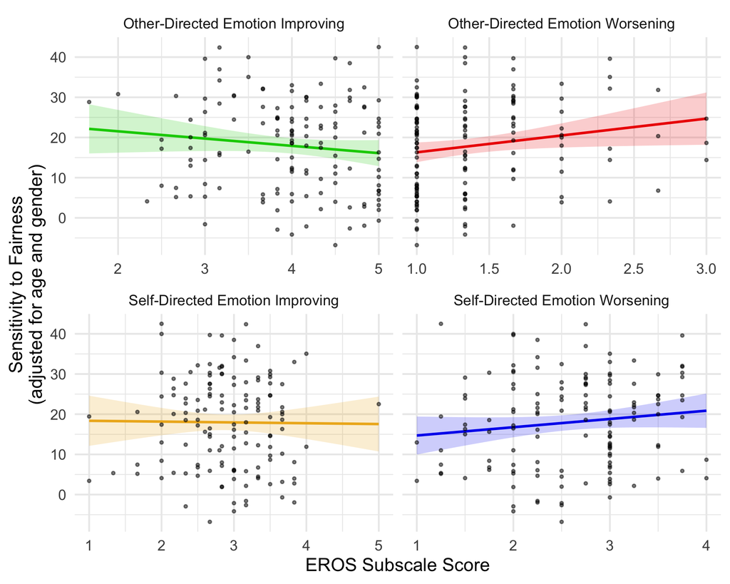

```r
# Sensitivity to fairness adjusted for age, gender (add mean back to keep original scale)
df_long <- df |>
  mutate(slope_adj = residuals(lm(slope_all ~ sub_age_MC + gender_female + gender_male)) + mean(slope_all)) |>
  select(slope_adj, ext_bet, ext_wor, int_bet, int_wor) |>
  pivot_longer(-slope_adj, names_to = "EROS_scale", values_to = "score")

df_long$EROS_scale <- factor(df_long$EROS_scale,
  levels = c("ext_bet", "ext_wor", "int_bet", "int_wor"),
  labels = c("Other-Directed Emotion Improving", "Other-Directed Emotion Worsening", "Self-Directed Emotion Improving", "Self-Directed Emotion Worsening"))

# Supp Figure 2: Subject-specific sensitivity to fairness × EROS (adjusted for age and gender)
p_supp_fairness_slope_eros <- ggplot(df_long, aes(x = score, y = slope_adj)) +
  geom_smooth(aes(color = EROS_scale, fill = EROS_scale),
    method = "lm",
    se = T,
    linewidth = 1.2,
    alpha = 0.2) +
  geom_point(size = 1, color = "black", alpha = 0.5) +
  facet_wrap(~ EROS_scale, scales = "free_x") +
  scale_color_manual(values = eros_cols) +
  scale_fill_manual(values = eros_cols) +
  guides(color = "none", fill = "none") +
  labs(
    x = "EROS Subscale Score",
    y = "Sensitivity to Fairness\n(adjusted for age and gender)") +
  theme_minimal(base_size = 18)
p_supp_fairness_slope_eros
```

## Distribution of EROS subscale scores (Supplemental figure 3)

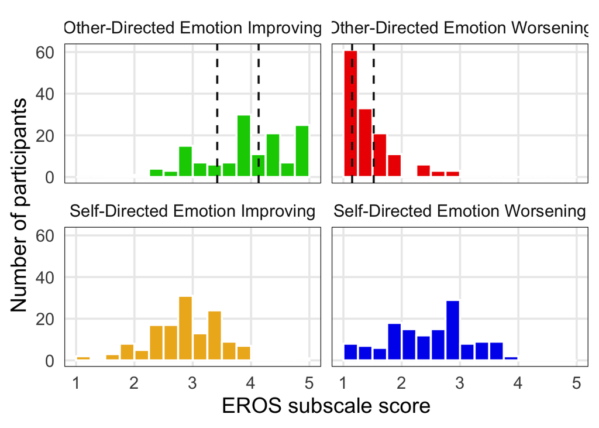

```r
eros_long <- df |>
  select(ext_bet, ext_wor, int_bet, int_wor) |>
  pivot_longer(everything(), names_to = "EROS_scale", values_to = "score") |>
  mutate(EROS_scale = factor(EROS_scale,
    levels = c("ext_bet", "ext_wor", "int_bet", "int_wor"),
    labels = names(eros_cols)))

jn_lines <- tibble(EROS_scale = factor(c("Other-Directed Emotion Improving", "Other-Directed Emotion Improving",
                        "Other-Directed Emotion Worsening", "Other-Directed Emotion Worsening"),
                      levels = names(eros_cols)),
  cutoff = c(3.42, 4.13, 1.15, 1.52))

p_supp_eros_hist <- ggplot(eros_long, aes(x = score, fill = EROS_scale)) +
  geom_histogram(binwidth = 0.25, boundary = 1, color = "white") +
  geom_vline(data = jn_lines, aes(xintercept = cutoff), linetype = "dashed", color = "gray10") +
  facet_wrap(~ EROS_scale) +
  scale_fill_manual(values = eros_cols) +
  scale_x_continuous(limits = c(1, 5), breaks = 1:5) +
  guides(fill = "none") +
  labs(x = "EROS subscale score", y = "Number of participants") +
  theme_minimal(base_size = 18) +
  theme(panel.grid.minor = element_blank(),
      panel.border = element_rect(color = "black", fill = NA, linewidth = 0.5))
p_supp_eros_hist
```

```r
# For figure captions, how many subs in significant regions
df |> summarise(eai_high = sum(ext_bet > 4.13), eai_mid = sum(ext_bet >= 3.42 & ext_bet <= 4.13), eai_low = sum(ext_bet < 3.42),
                eaw_high = sum(ext_wor > 1.52), eaw_mid = sum(ext_wor >= 1.15 & ext_wor <= 1.52), eaw_low = sum(ext_wor < 1.15))
```

```
## # A tibble: 1 × 6
##   eai_high eai_mid eai_low eaw_high eaw_mid eaw_low
##      <int>   <int>   <int>    <int>   <int>   <int>
## 1       64      40      34       44      33      61
```

# Export plots

```r
# Export selected plots for illustrator
out_dir <- here("figures")
dir.create(out_dir, recursive = T, showWarnings = F)

# Main figures now to illustrator
ggsave(file.path(out_dir, "Figure1_taskbehavior.pdf"), plot = p_fig1b, width = 8, height = 5, device = cairo_pdf)
ggsave(file.path(out_dir, "Figure2_EROS_fairness.pdf"), plot = p_fig2, width = 16, height = 9, device = cairo_pdf)
ggsave(file.path(out_dir, "Figure3_Categorical3b_AIns.pdf"), plot = p_fig3b, width = 8, height = 5, device = cairo_pdf)
ggsave(file.path(out_dir, "Figure4_act_dlPFC_jn.pdf"), plot = jn$plot, width = 8, height = 6, device = cairo_pdf)
ggsave(file.path(out_dir, "Figure5_PPI_Amyg_OFC.pdf"), plot = p_amygdala_ofc, width = 8, height = 6, device = cairo_pdf)
ggsave(file.path(out_dir, "Figure6B_PPI_Amyg_dmPFC_jn.pdf"), plot = jn2$plot, width = 8, height = 6, device = cairo_pdf)

# Supplemental figures (180 x 145 mm, 300 dpi)
ggsave(file.path(out_dir, "Supplement_figure1_fairness.tif"), plot = p_supp_fairness,
  width = 180, height = 145, units = "mm", dpi = 300, compression = "lzw", bg = "white")

ggsave(file.path(out_dir, "Supplement_figure2_participantLvl_EROS_fairness.tif"), plot = p_supp_fairness_slope_eros,
  width = 180, height = 145, units = "mm", dpi = 300, compression = "lzw", bg = "white")
ggsave(file.path(out_dir, "Supplement_figure3_EROSdistribution.tif"), plot = p_supp_eros_hist,
  width = 180, height = 145, units = "mm", dpi = 300, compression = "lzw", bg = "white")

ggsave(file.path(out_dir, "Supplement_figure4_dlPFC_extImp_scatter.tif"), plot = p_dlPFC_extbet,
  width = 180, height = 145, units = "mm", dpi = 300, compression = "lzw", bg = "white")
ggsave(file.path(out_dir, "Supplement_figure5_amygdala-dmPFC_extWor_scatter.tif"), plot = p_amygdala_extwor,
  width = 180, height = 145, units = "mm", dpi = 300, compression = "lzw", bg = "white")
```